# TerrainFlattening

```python
import datetime
import dateutil
import os
from glob import glob
from pathlib import Path
import xml.etree.ElementTree as ET

import tqdm
import matplotlib.pyplot as plt
import numpy as np
from scipy import interpolate
from scipy.linalg import norm
import geopandas as gpd
from shapely.geometry import Polygon, Point, LineString
import rasterio
import rasterio.mask
from rasterio.warp import calculate_default_transform, reproject, Resampling
import folium
import pymap3d
import pyproj
pyproj.network.set_network_enabled(True)
```

```python
def equalize_img(img, pmin=2, pmax=98):
    img = (img - np.percentile(img, pmin)) / (np.percentile(img, pmax) - np.percentile(img, pmin)) * 255
    img = np.clip(img, 0, 255).astype("uint8")
    return img
```

```python
img_root_dir = Path("../data/sentinel/S1A_IW_GRDH_1SDV_20220827T204353_20220827T204418_044743_0557A9_650C.SAFE")
img_path = img_root_dir / Path("measurement/s1a-iw-grd-vv-20220827t204353-20220827t204418-044743-0557a9-001.tiff")
annotation_path = img_root_dir / Path("annotation/s1a-iw-grd-vv-20220827t204353-20220827t204418-044743-0557a9-001.xml")
calibration_path = img_root_dir / Path("annotation/calibration/calibration-s1a-iw-grd-vv-20220827t204353-20220827t204418-044743-0557a9-001.xml")
footprint_path = img_root_dir / Path("preview/map-overlay.kml")

root = ET.parse(footprint_path)
for footprint in root.iter("coordinates"):
    footprint = [[float(lonlat.split(",")[0]), float(lonlat.split(",")[1])] for lonlat in footprint.text.split(" ")]
    footprint = Polygon(footprint)

tree = ET.parse(annotation_path)
root = tree.getroot()
sat_positions = []
for positions in root.iter("position"):
    sat_position = []
    for position in positions:
        sat_position.append(float(position.text))
    sat_positions.append(sat_position)
m = folium.Map(location=[footprint.centroid.y, footprint.centroid.x], zoom_start=6)
folium.GeoJson(footprint).add_to(m)
folium.GeoJson(LineString([pymap3d.ecef.ecef2geodetic(*position)[:2][::-1] for position in sat_positions])).add_to(m)

m
```

Make this Notebook Trusted to load map: File -> Trust Notebook

[interactive chart not shown]

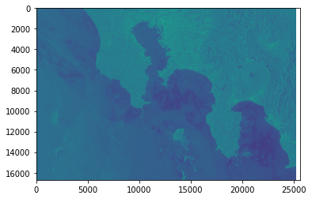

```python
with rasterio.open(img_path) as src:
    img = src.read(1)

plt.imshow(np.log(img))
plt.show()
```

# メタデータを使って、グローバル※な地形による輝度補正をする

※ 地形を楕円体とみなす

[Radiometric Calibration of S-1 Level-1 Products Generated by the S-1 IPF](https://sentinel.esa.int/documents/247904/685163/s1-radiometric-calibration-v1.0.pdf) によると、

$ \sigma_0 = \frac{DN^2}{A^2_{dn}K}\sin(\alpha) \\ A_\sigma = \sqrt{\frac{A^2_{dn}K}{\sin(\alpha)}} $

$A_\sigma$ は、sentinel-1 のメタデータで得られるので、DN値は以下のように後方散乱係数に変換される。

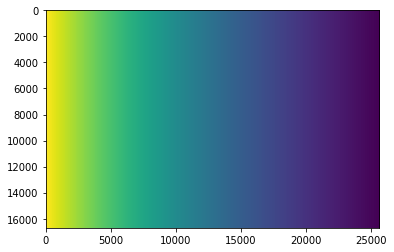

```python
# read sentinel-1 metadata
tree = ET.parse(calibration_path)
root = tree.getroot()

azimuthTimes = []
lines = []
pixels = []
sigmaNoughts = []
for calibrationVector in root.iter("calibrationVectorList"):
    for azimuthTime in calibrationVector.iter("azimuthTime"):
        azimuthTimes.append(dateutil.parser.parse(azimuthTime.text))
    for sigmaNought in calibrationVector.iter('sigmaNought'):
        sigmaNoughts.extend([float(x) for x in sigmaNought.text.split(" ")])
    for line, pixel in zip(calibrationVector.iter("line"), calibrationVector.iter("pixel")):
        lines.extend([int(line.text) for _ in range(int(pixel.get("count")))])
        pixels.extend([int(x) for x in pixel.text.split(" ")])

Y = np.arange(0, img.shape[0], 1)
X = np.arange(0, img.shape[1], 1)
lines = np.unique(lines)
pixels = np.unique(pixels)

# scipy.interpolate.interp2d だとうまく補完できなかった。　2d grid なら　RectBivariateSpline　が推奨されるらしい。
f_sigmaNought = interpolate.RectBivariateSpline(lines, pixels, np.array(sigmaNoughts).reshape(len(lines), len(pixels)))
sigmaNought = f_sigmaNought(Y, X)

plt.imshow(sigmaNought)
plt.show()
```

```python
img_flatten_db = 10 * np.log10(img / (sigmaNought**2))
img_db = 10 * np.log(img)
```

生データと地形（楕円体）による輝度補正をしたものを比較（両方とも dB 値）。

生データだと、衛星側（太平洋側）の方が地面に対するレーダーの断面積が広いので若干明るいが、それが補正されている。

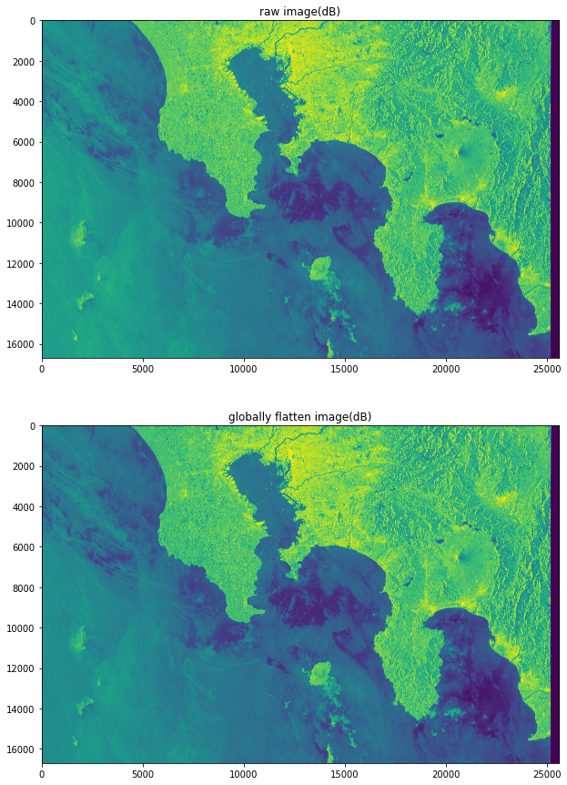

```python
fig, ax = plt.subplots(2, 1, figsize=(20, 15))
ax[0].imshow(equalize_img(img_db))
ax[0].set_title("raw image(dB)")
ax[1].imshow(equalize_img(img_flatten_db))
ax[1].set_title("globally flatten image(dB)")
plt.show()
```

海域における画像のピクセル値を、幅方向（レンジ方向）で比較。

補正前は、衛星側の方が明るいが、補正後はほぼフラットになっている。

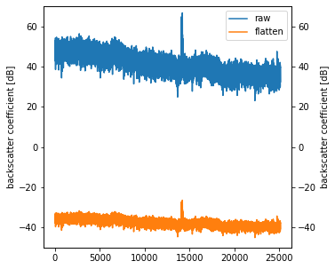

```python
fig, ax = plt.subplots(figsize=(5, 5))
lines = ax.plot(img_db[16000, :], c='C0', label="raw")
ax.set_ylim([-50, 70])
ax.set_ylabel("backscatter coefficient [dB]")
ax = ax.twinx()
lines += ax.plot(img_flatten_db[16000, :], c='C1', label="flatten")
ax.legend(lines, [line.get_label() for line in lines])
ax.set_ylim([-50, 70])
ax.set_ylabel("backscatter coefficient [dB]")
plt.show()
```

# 補正係数を軌道情報から雑に求める

補正係数は、$\alpha$ (local incident angle) = 楕円体表面へのレーダの入射角 の関数なので、絶対値を気にしないのであれば、雑に $\alpha$ だけで補正できる。

$ A_\sigma = \sqrt{\frac{C}{\sin(\alpha)}} \\ C: constant $

```python
# 衛星の位置・速度の補完関数を算出

tree = ET.parse(annotation_path)
root = tree.getroot()
sat_positions = []
for positions in root.iter("position"):
    sat_position = []
    for position in positions:
        sat_position.append(float(position.text))
    sat_positions.append(sat_position)

sat_velocities = []
for velocities in root.iter('velocity'):
    sat_velocity = []
    for velocity in velocities:
        sat_velocity.append(float(velocity.text))
    sat_velocities.append(sat_velocity)

orbit_timestamps = []
for orbit in root.iter("orbit"):
    for t in orbit.iter('time'):
        orbit_timestamps.append(dateutil.parser.parse(t.text).timestamp())
orbit_timestamp_ref = orbit_timestamps[0]
orbit_timestamps = [orbit_timestamp - orbit_timestamp_ref for orbit_timestamp in orbit_timestamps]

position_spline_funcs = []
for i in range(3):
    position_spline_funcs.append(interpolate.interp1d(orbit_timestamps, np.array(sat_positions)[:,i], kind='cubic'))

velocity_spline_funcs = []
for i in range(3):
    velocity_spline_funcs.append(interpolate.interp1d(orbit_timestamps, np.array(sat_velocities)[:,i], kind='cubic'))
```

```python
# read sentinel-1 grd image
with rasterio.open(img_path) as src:
    grd_img = src.read(1)

# read sentinel-1 metadata
tree = ET.parse(annotation_path)
root = tree.getroot()

lines = []
pixels = []
lats = []
lons = []
azimuth_times = []
for geolocationGrid in root.iter("geolocationGrid"):
    for geolocationGridPoint in geolocationGrid.iter("geolocationGridPoint"):
        for item in geolocationGridPoint.iter("line"):
            lines.append(int(item.text))
        for item in geolocationGridPoint.iter("pixel"):
            pixels.append(int(item.text))
        for item in geolocationGridPoint.iter("azimuthTime"):
            azimuth_times.append(dateutil.parser.parse(item.text).timestamp())
        for item in geolocationGridPoint.iter('latitude'):
            lats.append(float(item.text))
        for item in geolocationGridPoint.iter('longitude'):
            lons.append(float(item.text))

# 補完

Y = np.arange(0, max(lines), 1)
X = np.arange(0, max(pixels), 1)
lines = np.unique(lines)
pixels = np.unique(pixels)

f_longitude = interpolate.RectBivariateSpline(lines, pixels, np.array(lons).reshape(len(lines), len(pixels)))
f_latitude = interpolate.RectBivariateSpline(lines, pixels, np.array(lats).reshape(len(lines), len(pixels)))
f_azimuth_time = interpolate.RectBivariateSpline(lines, pixels, np.array(azimuth_times).reshape(len(lines), len(pixels)))
lons = f_longitude(Y, X)
lats = f_latitude(Y, X)
azimuth_time_sar = f_azimuth_time(Y, X) - orbit_timestamp_ref
```

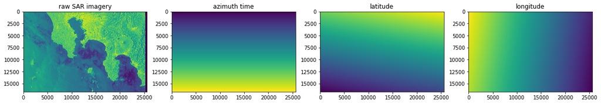

```python
fig, axx = plt.subplots(1, 4, figsize=(20, 5))
axx[0].imshow(equalize_img(img_db))
axx[0].set_title("raw SAR imagery")
axx[1].imshow(azimuth_time_sar)
axx[1].set_title("azimuth time")
axx[2].imshow(lats)
axx[2].set_title("latitude")
axx[3].imshow(lons)
axx[3].set_title("longitude")
plt.show()
```

```python
# 楕円体上の座標と、衛星の座標
surface_position = np.array(pymap3d.ecef.geodetic2ecef(lats, lons, np.zeros(lats.shape)))
sat_position = np.array([position_spline_func(azimuth_time_sar) for position_spline_func in position_spline_funcs])

# 楕円体の法線ベクトルと、衛星の視線ベクトル
norm_vector = np.array(pymap3d.ecef.geodetic2ecef(lats, lons, np.zeros(lats.shape) + 1)) - surface_position
norm_vector /= np.sqrt(np.sum(norm_vector**2, axis=0))
look_vector = surface_position - sat_position
look_vector /= np.sqrt(np.sum(look_vector**2, axis=0))

# 楕円体への入射角度
incident_angle = np.arccos(np.sum(norm_vector * look_vector, axis=0))

# 入射角度から補正係数を算出
coef = np.sqrt(1 / np.sin(incident_angle))
```

メタデータから得られた補正係数と、軌道情報から算出した補正係数の比較。

絶対値は異なるが、関数の形は同じ。

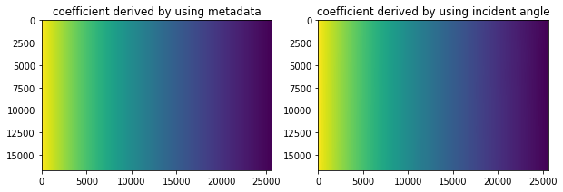

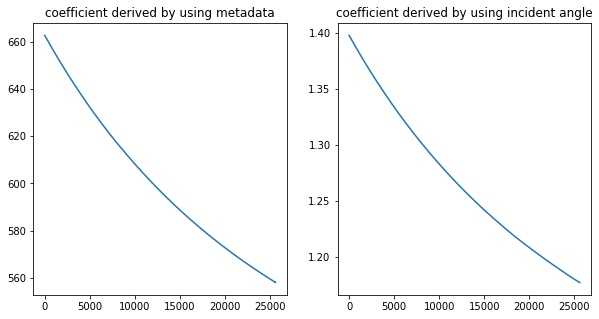

```python
fig, axx = plt.subplots(1, 2, figsize=(10, 5))
axx[0].imshow(sigmaNought)
axx[0].set_title("coefficient derived by using metadata")
axx[1].imshow(coef)
axx[1].set_title("coefficient derived by using incident angle")
plt.show()

fig, axx = plt.subplots(1, 2, figsize=(10, 5))
axx[0].plot(sigmaNought[10000, :])
axx[0].set_title("coefficient derived by using metadata")
axx[1].plot(coef[10000, :])
axx[1].set_title("coefficient derived by using incident angle")
plt.show()
```